# Pollinator_outline

Michelle DePrenger-Levin

Monday, September 28, 2015

DBG’s data  
look at NMDS for distance to disturbance or ADD IN scales of disturbance within different circles around the populaiton  
lm(richness~contour lines*distance)  
at some threshold of surrounding disturbance does proximity to disturbance have an effect so a buffer should be put into effect at some threshold?

```r
dbg_demo <- read.csv(path.expand("Q:/Research/All_Projects_by_Species/Sclerocactus SPECIES/Sclerocactus_glaucus/BlackHillsDocuments/2012_Black Hills/2012_data/Demographic data to Disturbance datacsv.csv"))

head(dbg_demo)
```

```
##   PlantID Max.Height Max.width Flowered NumberFl Browsed PhotoID
## 1    Pond        4.8       5.2        1        3       0      NA
## 2    Pond        1.5       1.7        0        0       0      NA
## 3    Pond        1.2       1.9        0        0       0      NA
## 4    Pond        2.2       4.3        1        3       0      NA
## 5    Pond        2.1       4.4        1        3       0      NA
## 6    Pond        1.8       1.5        0        0       0      NA
##       Comments Disturbance X_coord Y_coord dist_disturb_1 dir_distrub_1
## 1 formerly .34        Road  214509 4362024            143           170
## 2                     Road  214509 4362024            143           170
## 3                     Road  214509 4362024            143           170
## 4                     Road  214509 4362024            143           170
## 5 formerly .35        Road  214509 4362024            143           170
## 6 formerly .06        Road  214509 4362024            143           170
##   dist_disturb_2
## 1             NA
## 2             NA
## 3             NA
## 4             NA
## 5             NA
## 6             NA
```

# DBG pollination 2012

```r
pol <- read.csv(path.expand("Q:/Research/All_Projects_by_Species/Sclerocactus SPECIES/Sclerocactus_glaucus/BlackHillsDocuments/2012_Black Hills/2012_data/2012_SCGL_Pollination_Study.csv"))

head(pol)
```

```
##   Observer      Date   Site Plot X..plants X..flowers.open Quadrat.used.
## 1   Mergen 4/23/2012 SCGL64   NA         6               7            No
## 2   Mergen 4/23/2012 SCGL64   NA         6               7            No
## 3   Mergen 4/23/2012 SCGL64   NA         6               7            No
## 4   Mergen 4/23/2012 SCGL64   NA         6               7            No
## 5   Mergen 4/23/2012 SCGL64   NA         6               7            No
## 6   Mergen 4/23/2012 SCGL64   NA         6               7            No
##   Start.Time End.Time Temperature..Celcius. Wind.Speed..km.h. Pollinator.A
## 1     2:35pm   2:55pm                  33.9          8.5-13.3            9
## 2     2:55pm   3:15pm                  36.3          2.2-13.3           15
## 3     3:15pm   3:35pm                  34.0          1.1-13.3            9
## 4     3:35pm   3:55pm                  31.0         11.7-15.5           17
## 5     3:55pm   4:15pm                  33.5          3.8-15.5            3
## 6     4:15pm   4:35pm                  31.9          5.6-15.5            5
##    B  C  D  E  F  G  H BB BC Notes                  A.description
```

[output cut: 34 more lines]

```r
polsum <- read.csv(path.expand("Q:/Research/All_Projects_by_Species/Sclerocactus SPECIES/Sclerocactus_glaucus/BlackHillsDocuments/2012_Black Hills/2012_data/Pollination summary.csv"))

head(polsum)
```

```
##                         Pollinator ScGl87 ScGl87...west.end ScGl87...Daryl
## 1                 Small black ants     57                 8             27
## 2                        green bee    153               100            101
## 3             small flying bug/bee      9                14              9
## 4                 brombylius major      6                 1              4
## 5 bee stripes on butt (A April 23)      3                NA             NA
## 6           bumble bee (large bee)     22                 1             13
##   Scgl87...Daryl.May.9th ScGl70.East.side ScGl70...5.8.12.margaret
## 1                     30               NA                       NA
## 2                     95              105                      112
## 3                     NA               NA                        4
## 4                     NA               10                        5
## 5                     NA               NA                       NA
## 6                     NA               10                       NA
##   ScGl70...May.7.Mergen ScGl14...April.25
```

[output cut: 34 more lines]

Keep adding location for study points

```r
do.call(data.frame,lapply(split(pol, pol$Site), function(x){
  mean(rowSums(pol[,12:21], na.rm = TRUE))
}))
```

```
##     SCGL14   SCGL62   SCGL63   SCGL64
## 1 15.94737 15.94737 15.94737 15.94737
```

```r
totpol <- cbind(apply(polsum[,-1],2,FUN=function(x) sum(x, na.rm = TRUE)))


#lm( ,data=pol)
```

2013 study data of ScGl size by distance group to a disturbance

```r
ind13 <- read.csv(path.expand("Q:/Research/All_Projects_by_Species/Sclerocactus SPECIES/Sclerocactus_glaucus/BlackHillsDocuments/R code Black Hills/BlackHills_R_tables/2013_IndivData.csv"))

head(ind13)
```

```
##               Name Transect DistanceGroup Height.mm. Adj.Height.mm. Width
## 1 ExtraOilPad(Old)        1            10         97            111    62
## 2 ExtraOilPad(Old)        1            10        118            132    71
## 3 ExtraOilPad(Old)        1            10        117            131    60
## 4 ExtraOilPad(Old)        1            10         20             34    11
## 5 ExtraOilPad(Old)        1            10         46             60    57
## 6 ExtraOilPad(Old)        1            10        135            149   105
##   FlFr T.S Comments
## 1    3   T
## 2    6   T
## 3    2   T
## 4    0   T
## 5    5   S
## 6    7   S     dead
```

I’m pretty sure that T.S means if the plant is touching another or is seperate

```r
site13 <- read.csv(path.expand("Q:/Research/All_Projects_by_Species/Sclerocactus SPECIES/Sclerocactus_glaucus/BlackHillsDocuments/R code Black Hills/BlackHills_R_tables/2013_SiteData.csv"))

head(ind13)
```

```
##               Name Transect DistanceGroup Height.mm. Adj.Height.mm. Width
## 1 ExtraOilPad(Old)        1            10         97            111    62
## 2 ExtraOilPad(Old)        1            10        118            132    71
## 3 ExtraOilPad(Old)        1            10        117            131    60
## 4 ExtraOilPad(Old)        1            10         20             34    11
## 5 ExtraOilPad(Old)        1            10         46             60    57
## 6 ExtraOilPad(Old)        1            10        135            149   105
##   FlFr T.S Comments
## 1    3   T
## 2    6   T
## 3    2   T
## 4    0   T
## 5    5   S
## 6    7   S     dead
```

```r
polcheck <- read.csv(path.expand("Q:/Research/All_Projects_by_Species/Sclerocactus SPECIES/Sclerocactus_glaucus/BlackHillsDocuments/2012_Black Hills/2012_data/2013-02-27_Pollinator_types_check.csv"))

head(polcheck)
```

```
##   pollinator_ID pollination_ID       Pollinator X..of.Visits  X
## 1           340             48 Same as 23 April           18 NA
## 2           341             49 Same as 23 April           29 NA
## 3           343             50 Same as 23 April           40 NA
## 4           344             51 Same as 23 April           27 NA
## 5           345             52 Same as 23 April           39 NA
## 6           346             53 Same as 23 April           35 NA
##             Change.Pollinator.to...
## 1 A, less than 1 cm length, stripes
## 2 A, less than 1 cm length, stripes
## 3 A, less than 1 cm length, stripes
## 4 A, less than 1 cm length, stripes
## 5 A, less than 1 cm length, stripes
## 6 A, less than 1 cm length, stripes
```

```r
dist14 <- read.csv(path.expand("Q:/Research/All_Projects_by_Species/Sclerocactus SPECIES/Sclerocactus_glaucus/BlackHillsDocuments/R code Black Hills/BlackHills_R_tables/2014_ScGl_disturbancedata.csv"))

head(dist14)
```

```
##     Site Distance Biologic Width Height FrTot FrMat FrPred Seeds SeedsMat
## 1 Picnic     Near       NA   4.8    2.6     0     0      0     0        0
## 2 Picnic     Near       NA   2.0    2.0     0     0      0     0        0
## 3 Picnic     Near       NA   3.9    4.6     2     2      0     1        1
## 4 Picnic     Near       NA   7.7    8.7     4     4      4     1        1
## 5 Picnic     Near       NA   4.6    1.2     8     0      0     0        0
## 6 Picnic     Near       NA   1.4    0.6     0     0      0     0        0
##   SeedCol Polygon
## 1      NA       1
## 2      NA       1
## 3      NA       1
## 4      NA       1
## 5      NA       1
## 6      NA       1
```

```r
germ14 <- read.csv(path.expand("Q:/Research/All_Projects_by_Species/Sclerocactus SPECIES/Sclerocactus_glaucus/BlackHillsDocuments/R code Black Hills/BlackHills_R_tables/2014_ScGl_germinationHeightWidth.csv"))

head(germ14)
```

```
##   NearFar Site PotNum Height Width
## 1    Near Fram      1    1.7   1.0
## 2    Near Fram      1    0.3   0.1
## 3    Near Fram      3    1.4   0.1
## 4    Near Fram      6    1.2   0.3
## 5    Near Fram      9    1.8   0.3
## 6    Near Fram     10    1.0   0.3
```

### 2014 germination of seeds in Becky’s office

Need to split the top rows that have date and temperatures from the bottom that give the number of seeds germinated per pot of near or far at each site

```r
germ14_all <- read.csv(path.expand("Q:/Research/All_Projects_by_Species/Sclerocactus SPECIES/Sclerocactus_glaucus/BlackHillsDocuments/R code Black Hills/BlackHills_R_tables/Germination_ScGl_study2_2014.csv"))

head(germ14_all)
```

```
##                               Rotating.pots.one.spot.each.day    X
## 1 Far right moves to far left, all else move one to the right
## 2
## 3                                                     NearFar Site
## 4                                                        Near Fram
## 5                                                        Near Fram
## 6                                                        Near Fram
##          X.1             X.2      X.3    X.4         X.5      X.6
## 1
## 2
## 3 Individual IndividualColor NumSeeds PotNum     IndSize IndWidth
## 4      1-12C          yellow        9      1 199.4283016      9.2
## 5      1-19A            blue       10      2 145.5499876      8.2
## 6      1-11C            blue       11      3 167.4154725      7.3
##   High...F.     X99   X99.1   X99.2     X82     X83     X81     X84
```

[output cut: 76 more lines]

Access database “Q:_Projects_by_SpeciesSPECIES_glaucusHills Disturbance.mdb"

```r
pol12 <- read.csv(path.expand("Q:/Research/All_Projects_by_Species/Sclerocactus SPECIES/Sclerocactus_glaucus/BlackHillsDocuments/R code Black Hills/BlackHills_R_tables/Pollinators.csv"))

head(pol12)
```

```
##     Plot  plant dist     Date NumPl NumOpenFl minwind WindSpeed Temp
## 1 SCGL87 scgl87  185 5/9/2012     4         7      NA       0.9 27.6
## 2 SCGL87 scgl87  185 5/9/2012     4         7      NA       0.9 27.6
## 3 SCGL87 scgl87  185 5/9/2012     4         7      NA       0.9 27.6
## 4 SCGL87 scgl87  185 5/9/2012     4         7      NA       0.3 29.3
## 5 SCGL87 scgl87  185 5/9/2012     4         7      NA       0.3 29.3
## 6 SCGL87 scgl87  185 5/9/2012     4         7      NA       0.3 29.3
##   Start.Time           Pollinator Visits
## 1 1:20:00 PM     Small Black Ants      5
## 2 1:20:00 PM            Green Bee     12
## 3 1:20:00 PM Small Flying bug/bee      1
## 4 1:40:00 PM Small Flying bug/bee      3
## 5 1:40:00 PM      Bombylius major      5
## 6 1:40:00 PM     Small Black Ants      3
```

From Access??

```r
samsize <- read.csv(path.expand("Q:/Research/All_Projects_by_Species/Sclerocactus SPECIES/Sclerocactus_glaucus/BlackHillsDocuments/R code Black Hills/BlackHills_R_tables/qry_Sample Size_AllYears.csv"))

head(samsize)
```

```
##           SiteName X2012.Site.Name Transect.number Transect.letter
## 1 Atwell Gulch_108    Atwell Gulch              15
## 2 Atwell Gulch_108    Atwell Gulch              11
## 3 Atwell Gulch_108    Atwell Gulch              11
## 4 Atwell Gulch_108    Atwell Gulch              11
## 5 Atwell Gulch_108    Atwell Gulch              11
## 6 Atwell Gulch_108    Atwell Gulch              11
##   Transect.length    Tag X.coord..0.100cm. Y.coord..m. Year Height..cm.
## 1              30 186.01              0.34        26.6 2010         3.3
## 2              30 200.07              0.14        12.1 2011         0.3
## 3              30 200.06              0.14        12.1 2011         0.3
## 4              30 200.05              0.14        12.1 2011         0.3
## 5              30 200.04              0.14        12.1 2011         0.3
## 6              30 200.03              0.14        12.1 2011         0.3
##   Width..cm. Flowered..y.n. Browsed..y.n. Minis
## 1        4.5              1             0    NA
## 2        0.3              0             0    NA
## 3        0.3              0             0    NA
## 4        0.3              0             0    NA
## 5        0.3              0             0    NA
## 6        0.3              0             0    NA
```

### Soil samples from two north and two south sites 2015

```r
soil <- read.csv(path.expand("Q:/Research/All_Projects_by_Species/Sclerocactus SPECIES/Sclerocactus_glaucus/BlackHillsDocuments/2015_Black Hills/SoilSamplesResults.csv"))

head(soil)
```

```
##           Site  pH  EC      Lime         Texture sant silt clay
## 1         Fram 7.8 2.4 very high silty clay loam   11   51   38
## 2 Pyramid Rock 8.2 5.6       low            clay   22   37   41
## 3       Picnic 8.4 2.3 very high       clay loam   25   47   28
## 4         Pond 8.0 0.7       low      silty clay    8   50   42
##   Organic.mat nitrate Phosphorus Potassium Zinc Iron Manganese Copper
## 1         1.4       2        3.0     151.3  0.5  3.1       2.0    1.6
## 2         0.7      16        0.9     193.3  0.5  7.9       1.5    1.1
## 3         1.2       1        6.9     229.0  0.3  5.2       3.6    1.4
## 4         0.8       8        0.6     110.4  0.3  5.4       0.6    3.7
##   Boron     Gypsum
## 1   0.5 not needed
## 2   0.5 not needed
## 3   0.5 not needed
## 4   0.5 not needed
```

Compare soil samples with seed germination rate, germination  
for ANOVA: fixed would be near far, random would be site since I want to generalize to other sites?  
Use Anova in with type=“III” which works best for unbalanced design

```r
maxgerm <- as.numeric(apply(seed[,10:103],1,function(x) max(x, na.rm=TRUE)))
seedmax <- data.frame(seed,maxgerm)
seed.soil <- merge(seedmax, soil, by.x = "X", by.y = "Site")

names(seed.soil)[2] <- "NF"
names(seed.soil)[1] <- "Site"

summary(lm(maxgerm~Site*NF, data=seed.soil))
```

```
##
## Call:
## lm(formula = maxgerm ~ Site * NF, data = seed.soil)
##
## Residuals:
##    Min     1Q Median     3Q    Max
##   -1.4   -0.5    0.0    0.5    3.1
##
## Coefficients: (1 not defined because of singularities)
##                         Estimate Std. Error t value Pr(>|t|)
## (Intercept)               0.9000     0.2732   3.294   0.0017 **
## SitePicnic                0.6000     0.3864   1.553   0.1260
## SitePond                 -0.9000     0.3864  -2.329   0.0234 *
## SitePyramid Rock         -0.5000     0.3864  -1.294   0.2009
## NFNear                   -0.1000     0.3864  -0.259   0.7967
## SitePicnic:NFNear             NA         NA      NA       NA
## SitePond:NFNear           0.3500     0.6408   0.546   0.5870
## SitePyramid Rock:NFNear   0.2000     0.5464   0.366   0.7157
## ---
## Signif. codes:  0 '***' 0.001 '**' 0.01 '*' 0.05 '.' 0.1 ' ' 1
##
## Residual standard error: 0.864 on 57 degrees of freedom
## Multiple R-squared:  0.2226, Adjusted R-squared:  0.1408
## F-statistic:  2.72 on 6 and 57 DF,  p-value: 0.02153
```

## HSD Tukey test

```r
library(agricolae)
model <- lm(maxgerm~Site*NF, data=seed.soil)
HSD.test(model,list("NF","Site"), group=TRUE, console=TRUE)
```

```
##
## Study: model ~ list("NF", "Site")
##
## HSD Test for maxgerm
##
## Mean Square Error:  0.7464912
##
## NF:Site,  means
##
##                   maxgerm       std  r Min Max
## Far:Fram             0.90 1.2866839 10   0   4
## Far:Pond             0.00 0.0000000 10   0   0
## Far:Pyramid Rock     0.40 0.6992059 10   0   2
## Near:Fram            0.80 1.0327956 10   0   3
## Near:Picnic          1.40 1.0749677 10   0   3
## Near:Pond            0.25 0.5000000  4   0   1
## Near:Pyramid Rock    0.50 0.5270463 10   0   1
##
## alpha: 0.05 ; Df Error: 57
## Critical Value of Studentized Range: 4.321902
##
## Harmonic Mean of Cell Sizes  8.235294
## Honestly Significant Difference: 1.301211
##
## Means with the same letter are not significantly different.
##
## Groups, Treatments and means
## a     Near:Picnic         1.4
## ab    Far:Fram            0.9
## ab    Near:Fram           0.8
## ab    Near:Pyramid Rock   0.5
## ab    Far:Pyramid Rock    0.4
## ab    Near:Pond           0.25
## b     Far:Pond            0
```

Rate of germination?

# Bio-Logic data

bl_scgl has both glaucus and brevispinus but no wetlandicus

```r
bl_scgl <- read.csv(path.expand("Q:/Research/All_Projects_by_Species/Sclerocactus SPECIES/Sclerocactus_glaucus/BIO-Logic/scgl_2012.csv"), skip = 3, na.strings = "9999")

head(bl_scgl)
```

```
##   Species Group Plot. Categ. Meas. No. Nbr. Max.Dia. Max.Ht. Volume. Buds
## 1    SCBR     W     1   Near  21.6 101    1     3.71    2.15   13.37    0
## 2    SCBR     W     1   Near  18.2 102    1     2.79    1.58    5.69    0
## 3    SCBR     W     1   Near  80.3 103    0     3.04    1.02    7.36    0
## 4    SCBR     W     1   Near  31.7 104    0     4.78    2.08   28.59    0
## 5    SCBR     W     1   Near  33.4 105    0     3.41    1.55   10.38    0
## 6    SCBR     W     1   Near  33.0 106    0     2.97    1.61    6.86    0
##   Flwrs Fruits.1 Fruits.2 Frt.Flwr UTM..mE. UTM..mN. Count Notes DBG
## 1     0        0       NA       NA  4437427   584727    NA
## 2     0        0       NA       NA  4437431   584716    NA
## 3     0        0       NA       NA  4437368   584729    NA
## 4     2        0       NA        0  4437417   584727    NA     1
## 5     0        0       NA       NA  4437413   584771    NA
## 6     0        0       NA       NA  4437413   584765    NA
##   Flwrs.1                             Expanded.Notes...Comments  X X.1 X.2
```

[output cut: 20 more lines]

## Results

Bio-logic  
Nbr: count of number of cactus within 10cm of marked plant  
Group: E(ast) or W(est) for scbr and N(orth) S(outh) for scgl

# Calculate volume same way!

```
## stat_bin: binwidth defaulted to range/30. Use 'binwidth = x' to adjust this.
```

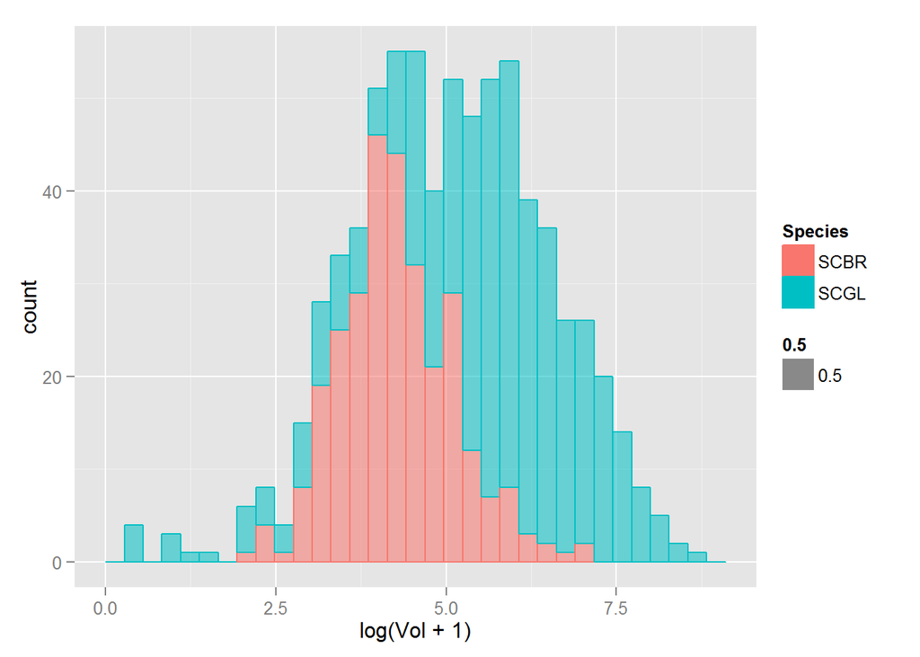

```r
bl_scgl$Vol <- pi*(bl_scgl$Max.Dia.^2)*bl_scgl$Max.Ht.

#ScGl and ScBr
ggplot(bl_scgl, aes(log(Vol+1), colour = Species, fill = Species, alpha = 0.5)) +
  geom_histogram()
```

```r
summary(lm(log(Vol+1) ~ Meas.*Species, data = bl_scgl))
```

```
##
## Call:
## lm(formula = log(Vol + 1) ~ Meas. * Species, data = bl_scgl)
##
## Residuals:
##     Min      1Q  Median      3Q     Max
## -5.3791 -0.5729  0.0697  0.7435  2.9441
##
## Coefficients:
##                     Estimate Std. Error t value Pr(>|t|)
## (Intercept)        4.5105891  0.1133982  39.777  < 2e-16 ***
## Meas.             -0.0008002  0.0003306  -2.420   0.0158 *
## SpeciesSCGL        1.2212669  0.1562572   7.816 1.96e-14 ***
## Meas.:SpeciesSCGL  0.0000247  0.0006153   0.040   0.9680
## ---
## Signif. codes:  0 '***' 0.001 '**' 0.01 '*' 0.05 '.' 0.1 ' ' 1
##
## Residual standard error: 1.249 on 714 degrees of freedom
##   (7 observations deleted due to missingness)
## Multiple R-squared:  0.2139, Adjusted R-squared:  0.2106
## F-statistic: 64.75 on 3 and 714 DF,  p-value: < 2.2e-16
```

```r
summary(lm(log(Vol+1) ~ Categ.*Species, data = bl_scgl))
```

```
##
## Call:
## lm(formula = log(Vol + 1) ~ Categ. * Species, data = bl_scgl)
##
## Residuals:
##     Min      1Q  Median      3Q     Max
## -5.4179 -0.5711  0.0833  0.7291  2.9207
##
## Coefficients:
##                        Estimate Std. Error t value Pr(>|t|)
## (Intercept)             4.11586    0.09853  41.772  < 2e-16 ***
## Categ.Near              0.38193    0.14595   2.617  0.00906 **
## SpeciesSCGL             1.35961    0.12842  10.587  < 2e-16 ***
## Categ.Near:SpeciesSCGL -0.11721    0.18934  -0.619  0.53609
## ---
## Signif. codes:  0 '***' 0.001 '**' 0.01 '*' 0.05 '.' 0.1 ' ' 1
##
## Residual standard error: 1.246 on 719 degrees of freedom
##   (2 observations deleted due to missingness)
## Multiple R-squared:  0.2211, Adjusted R-squared:  0.2178
## F-statistic: 68.03 on 3 and 719 DF,  p-value: < 2.2e-16
```

```r
biol <- bl_scgl[,c(1:21,46)]
table(biol$Species)
```

```
##
## SCBR SCGL
##  294  431
```

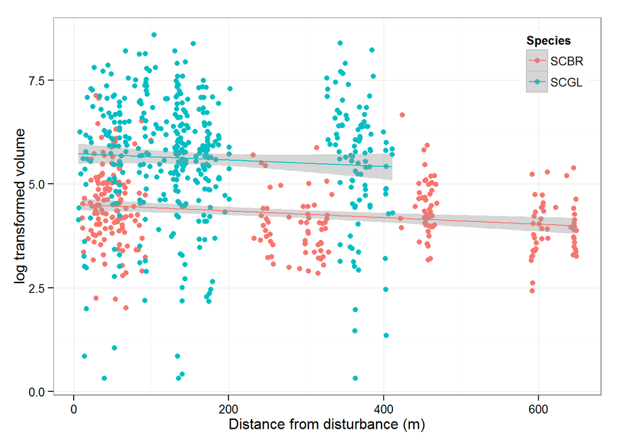

```r
ggplot(biol, aes(Meas., log(Vol+1), colour = Species)) +
  geom_point() +
  stat_smooth(method = "lm") +
  theme_bw() +
  theme(legend.justification=c(1,1),legend.position=c(1,1)) +
  xlab("Distance from disturbance (m)") +
  ylab("log transformed volume")
```

Combind biologic and dbg

```r
dbg_demo$Vol <- pi*(dbg_demo$Max.width^2)*dbg_demo$Max.Height
biol.2c <- biol[,c(1,5,22)]
dbg.2c <- data.frame(Species="SCGL", Meas.=dbg_demo[,12], Vol=dbg_demo$Vol)
comb_vol <- rbind(biol.2c, dbg.2c)
```

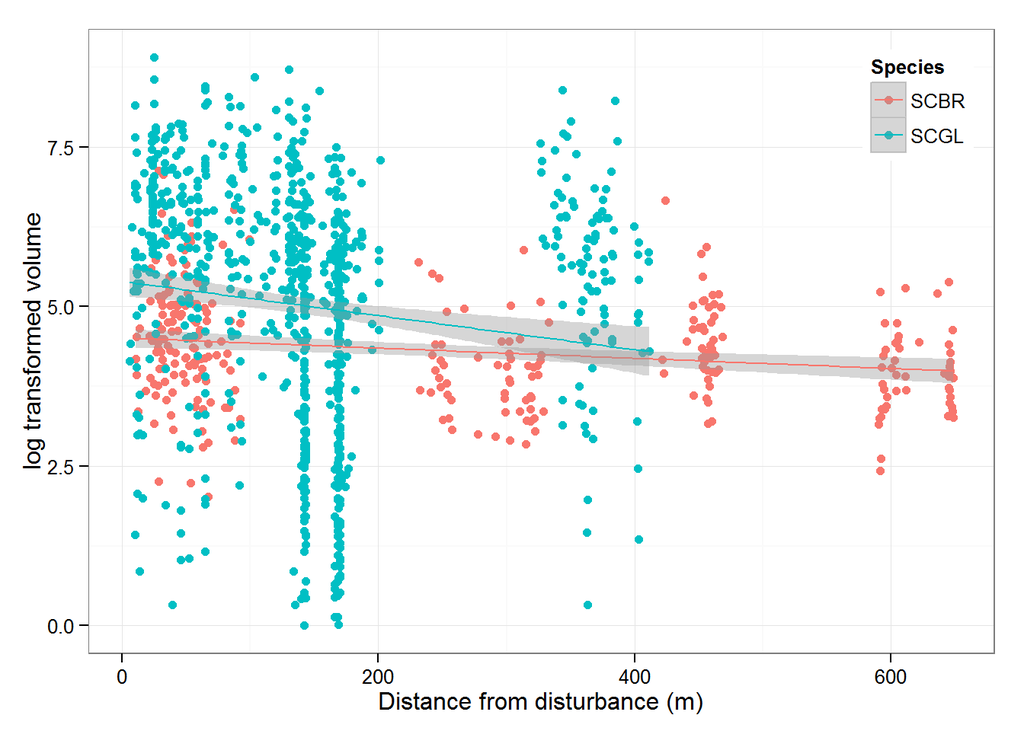

```r
ggplot(comb_vol, aes(Meas., log(Vol+1), colour = Species)) +
  geom_point() +
  stat_smooth(method = "lm") +
  theme_bw() +
  theme(legend.justification=c(1,1),legend.position=c(1,1)) +
  xlab("Distance from disturbance (m)") +
  ylab("log transformed volume")
```

```r
summary(lm(log(Vol+1) ~ Meas.*Species, data = comb_vol))
```

```
##
## Call:
## lm(formula = log(Vol + 1) ~ Meas. * Species, data = comb_vol)
##
## Residuals:
##     Min      1Q  Median      3Q     Max
## -5.0126 -0.8771  0.2131  1.2044  3.9196
##
## Coefficients:
##                     Estimate Std. Error t value Pr(>|t|)
## (Intercept)        4.5105891  0.1559301  28.927  < 2e-16 ***
## Meas.             -0.0008002  0.0004546  -1.760   0.0787 .
## SpeciesSCGL        0.8876516  0.1884308   4.711 2.77e-06 ***
## Meas.:SpeciesSCGL -0.0018806  0.0007612  -2.471   0.0136 *
## ---
## Signif. codes:  0 '***' 0.001 '**' 0.01 '*' 0.05 '.' 0.1 ' ' 1
##
## Residual standard error: 1.718 on 1139 degrees of freedom
##   (9 observations deleted due to missingness)
## Multiple R-squared:  0.04949,    Adjusted R-squared:  0.04699
## F-statistic: 19.77 on 3 and 1139 DF,  p-value: 1.703e-12
```

```r
head(dbg_demo)
```

```
##   PlantID Max.Height Max.width Flowered NumberFl Browsed PhotoID
## 1    Pond        4.8       5.2        1        3       0      NA
## 2    Pond        1.5       1.7        0        0       0      NA
## 3    Pond        1.2       1.9        0        0       0      NA
## 4    Pond        2.2       4.3        1        3       0      NA
## 5    Pond        2.1       4.4        1        3       0      NA
## 6    Pond        1.8       1.5        0        0       0      NA
##       Comments Disturbance X_coord Y_coord dist_disturb_1 dir_distrub_1
## 1 formerly .34        Road  214509 4362024            143           170
## 2                     Road  214509 4362024            143           170
## 3                     Road  214509 4362024            143           170
## 4                     Road  214509 4362024            143           170
## 5 formerly .35        Road  214509 4362024            143           170
## 6 formerly .06        Road  214509 4362024            143           170
##   dist_disturb_2       Vol
## 1             NA 407.75359
## 2             NA  13.61880
## 3             NA  13.60938
## 4             NA 127.79371
## 5             NA 127.72459
## 6             NA  12.72345
```

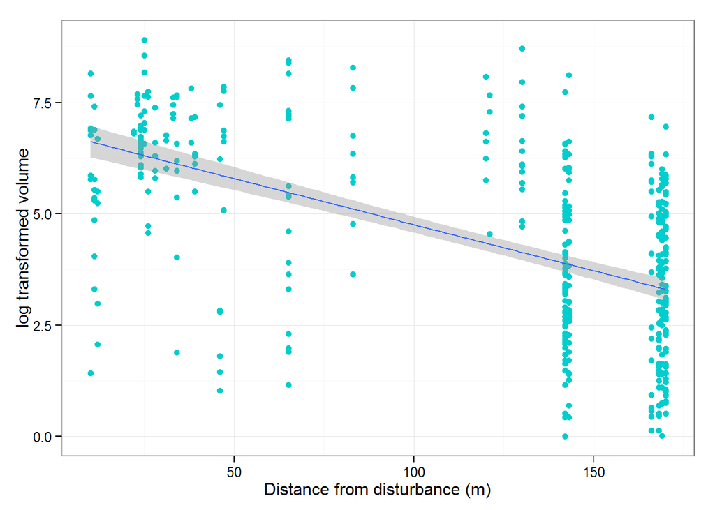

```r
ggplot(dbg_demo, aes(dist_disturb_1, log(Vol+1))) +
  geom_point(colour = "cyan3")+
  stat_smooth(method = "lm") +
  theme_bw() +
  theme(legend.justification=c(1,1),legend.position=c(1,1)) +
  xlab("Distance from disturbance (m)") +
  ylab("log transformed volume")
```

## Check same with ind13

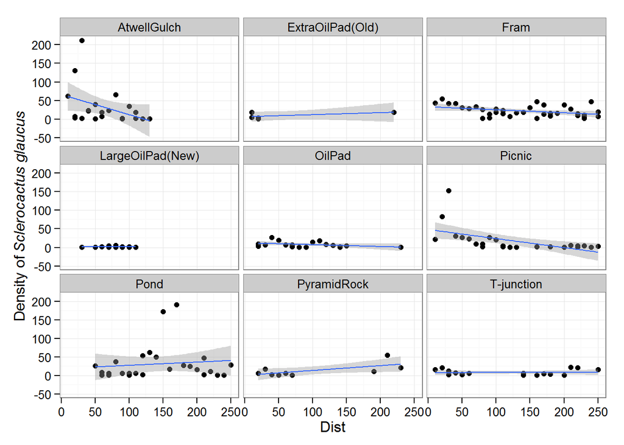

```r
ind13$Vol <- pi*(ind13$Width^2)*ind13$Adj.Height.mm.
ind13_1 <- ind13[ind13$Vol != 0,]
density <- aggregate(ind13_1$Vol,
                     list(Dist = ind13_1$DistanceGroup,
                          Site = ind13_1$Name,
                          Transect = ind13_1$Transect), length)

ggplot(density, aes(Dist,x))+
  geom_point()+
  stat_smooth(method="lm")+
  ylab(substitute(paste("Density of ", italic("Sclerocactus glaucus"))))+
  theme_bw()+
  facet_wrap(~Site)
```

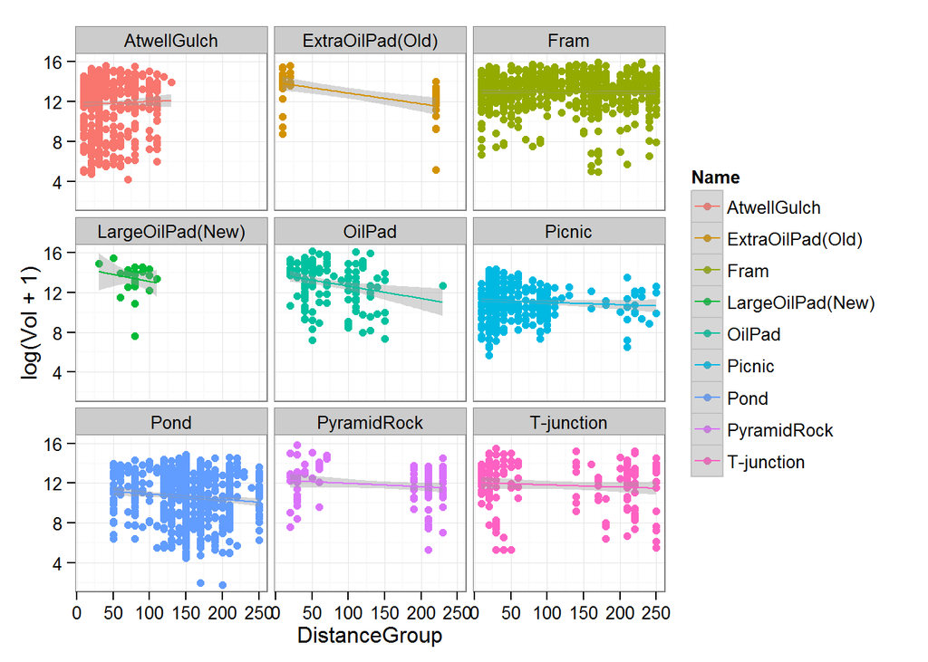

```r
ggplot(ind13_1, aes(DistanceGroup,log(Vol+1),colour=Name))+
  geom_point()+
  stat_smooth(aes(group=Name), method="lm")+
  facet_wrap(~Name)+
  theme_bw()
```

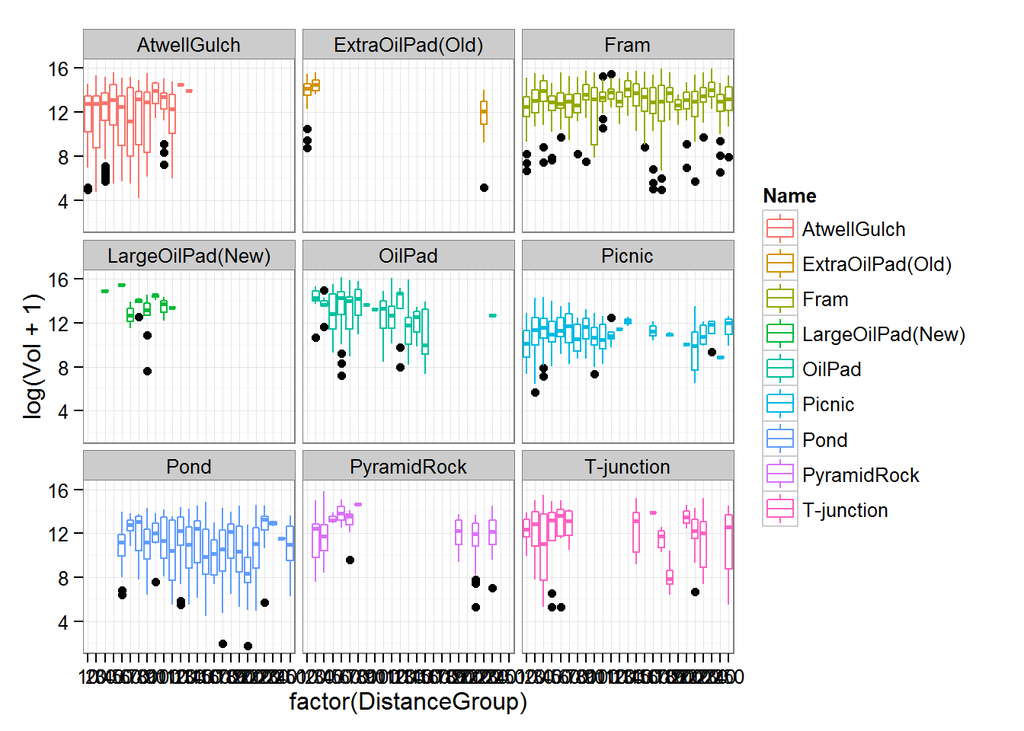

```r
ggplot(ind13_1, aes(factor(DistanceGroup),log(Vol+1),colour=Name))+
  geom_boxplot()+
  facet_wrap(~Name)+
  theme_bw()
```

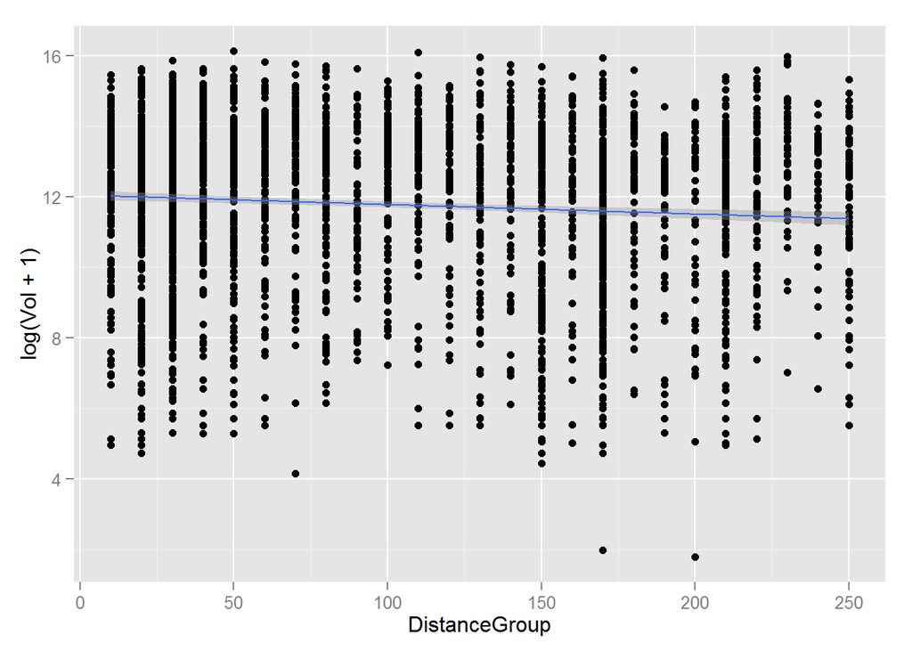

```r
ggplot(ind13_1, aes(DistanceGroup,log(Vol+1)))+
  geom_point()+
  stat_smooth(method="lm")
```

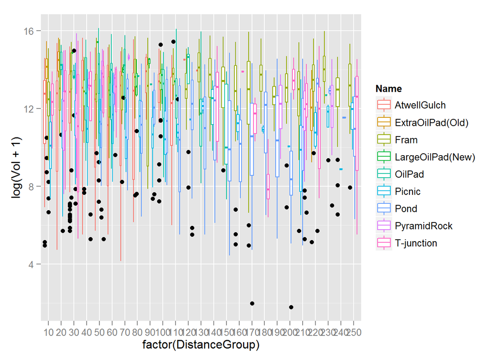

```r
ggplot(ind13_1, aes(factor(DistanceGroup),log(Vol+1), colour = Name))+
  geom_boxplot()
```

proportion of size in populations  
from DBG 2012-12-03 report: The average size of vegetative individuals at Black Hills sites was 54.6 cm3 (±10.2 SD). Black Hills individuals are significantly more likely to be reproductive once they reach 163.7 cm3 (± 2.8; t = -34.1, df = 1077.2, p < 0.001). Individuals are significantly smaller as the distance from a disturbance increases (r2 = 0.07, F(1,1158) = 82.2, p < 0.001; Figure 5a).

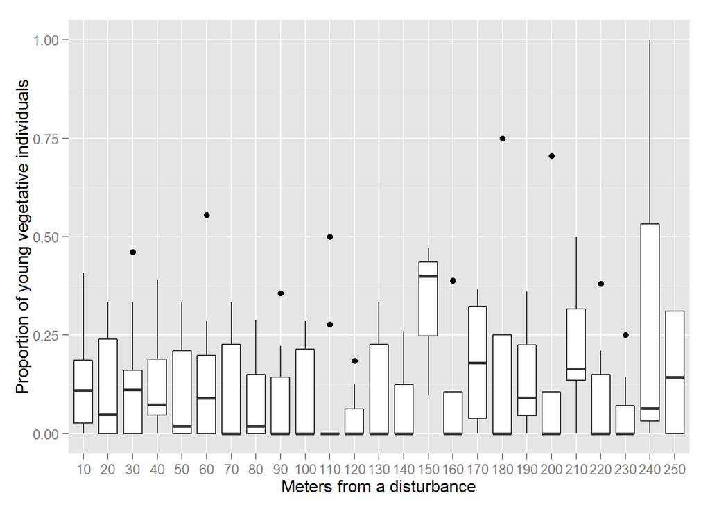

```r
prop_sm <- aggregate(ind13_1$Vol,by=list(Site = ind13_1$Name,
                              Dist = ind13_1$DistanceGroup,
                              Transect = ind13_1$Transect),
          function(x){
            length(x[x <16370])/length(x)
            })

ggplot(prop_sm, aes(factor(Dist),x))+
  geom_boxplot()+
  ylab("Proportion of young vegetative individuals")+
  xlab("Meters from a disturbance")
```

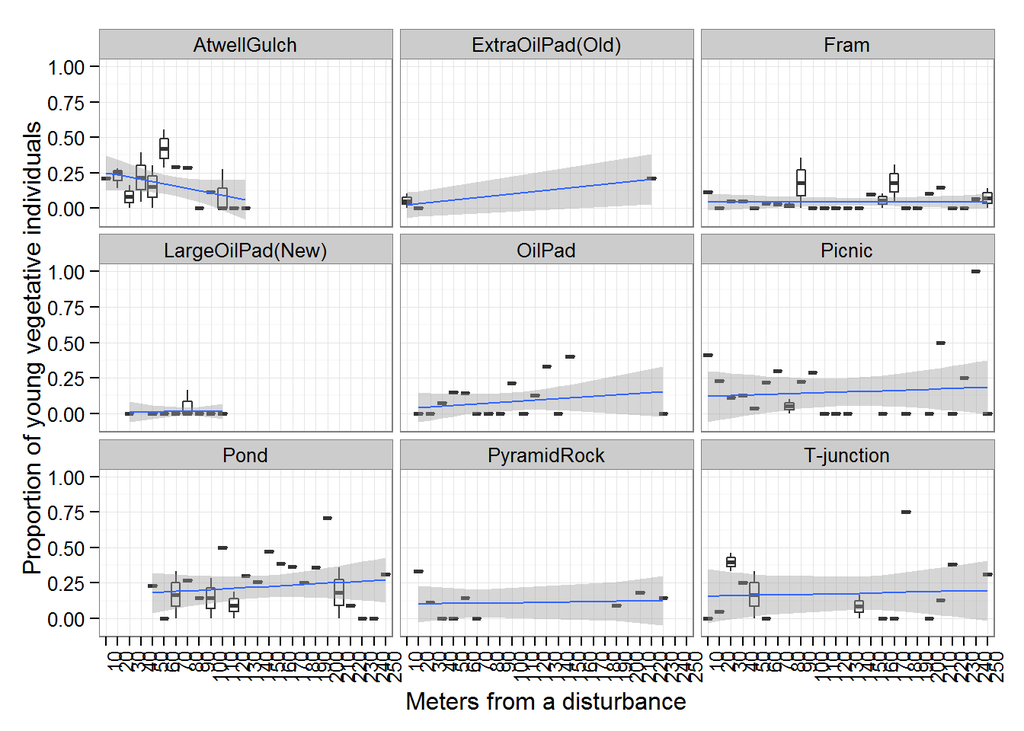

```r
ggplot(prop_sm, aes(factor(Dist),x))+
  geom_boxplot()+
  stat_smooth(aes(group=Site), method="lm")+
  ylab("Proportion of young vegetative individuals")+
  xlab("Meters from a disturbance")+
  facet_wrap(~Site)+
  theme_bw()+
  theme(axis.text.x=element_text(angle=90,hjust=1))
```

```r
summary(lm(x~Dist*Site, data=prop_sm))
```

```
##
## Call:
## lm(formula = x ~ Dist * Site, data = prop_sm)
##
## Residuals:
##      Min       1Q   Median       3Q      Max
## -0.26804 -0.09279 -0.02266  0.07973  0.81780
##
## Coefficients:
##                             Estimate Std. Error t value Pr(>|t|)
## (Intercept)                0.2672585  0.0705723   3.787 0.000218 ***
## Dist                      -0.0015861  0.0009415  -1.685 0.094087 .
## SiteExtraOilPad(Old)      -0.2533982  0.1122618  -2.257 0.025392 *
## SiteFram                  -0.2233638  0.0924202  -2.417 0.016818 *
## SiteLargeOilPad(New)      -0.2595628  0.1841522  -1.410 0.160690
## SiteOilPad                -0.2360467  0.1037235  -2.276 0.024232 *
## SitePicnic                -0.1492160  0.0952107  -1.567 0.119103
## SitePond                  -0.1087017  0.1069363  -1.017 0.310971
## SitePyramidRock           -0.1673960  0.1115117  -1.501 0.135351
## SiteT-junction            -0.1114454  0.0984898  -1.132 0.259574
## Dist:SiteExtraOilPad(Old)  0.0024664  0.0012876   1.915 0.057276 .
## Dist:SiteFram              0.0015991  0.0010157   1.574 0.117451
## Dist:SiteLargeOilPad(New)  0.0016520  0.0023126   0.714 0.476077
## Dist:SiteOilPad            0.0021180  0.0011841   1.789 0.075617 .
## Dist:SitePicnic            0.0018534  0.0010390   1.784 0.076397 .
## Dist:SitePond              0.0020422  0.0010744   1.901 0.059186 .
## Dist:SitePyramidRock       0.0017018  0.0011588   1.469 0.143990
## Dist:SiteT-junction        0.0017535  0.0010554   1.661 0.098639 .
## ---
## Signif. codes:  0 '***' 0.001 '**' 0.01 '*' 0.05 '.' 0.1 ' ' 1
##
## Residual standard error: 0.1613 on 155 degrees of freedom
## Multiple R-squared:  0.1905, Adjusted R-squared:  0.1017
## F-statistic: 2.146 on 17 and 155 DF,  p-value: 0.007671
```

## look at germination data from last year to see if seed germination differs near to far

```r
seed <- germ14_all[-c(1:3),]
names.seed <- germ14_all[3,]
names(seed) <- names.seed
```

## Need to get pollinator abundance and richness values from Biologic for analysis

PBO: percent of bowl occupied out of 99

```r
blbees <- read.csv(path.expand("Q:/Research/All_Projects_by_Species/Sclerocactus SPECIES/Sclerocactus_glaucus/BIO-Logic/table14_diversityevennessbees.csv"))

head(blbees)
```

```
##   Site Dist Shannon srank Simpson sirank Evenness erank Chao.2 crank
## 1  11N    N     2.3    7)     1.4     7)    0.003    8)   65.0    6)
## 2  12I    I     2.1    8)     1.4     8)    0.032    7)   59.7    7)
## 3  13N    N     7.4    2)     3.2     3)    0.053    3)   76.9    4)
## 4  14N    N     8.1    1)     3.5     2)    0.052    4)  127.0    1)
## 5  15I    I     4.2    4)     2.4     4)    0.055    2)   99.1    3)
## 6  16I    I     4.2    5)     2.0     5)    0.043    5)  108.0    2)
##   MichMen mrank  X1  X2   X3  X4 Total   PBO AvgBee.bowl1 AvgBee.bowl2
## 1    83.2    6)  97 911 1062  NA  2070 100.0          3.3         25.4
## 2    93.8    4)  32 928 1039  NA  1999  99.0          1.1         25.4
## 3    90.0    5) 446 479  472  NA  1397  88.2         12.1         12.3
## 4   130.0    1) 280 355  513  NA  1148 100.0          7.0          9.6
## 5    95.1    2)  NA 699  313 150  1162  97.0           NA         18.5
## 6    82.4    7)  NA 605  304 108  1017  93.5           NA         20.1
##   AvgBee.bowl3 AvgBee.bowl4 Total.1 bowls NumBeeSp1 NumBeeSp2 NumBeeSp3
## 1         29.2           NA    20.0    95        12        27        36
## 2         29.5           NA    19.5    93         4        25        33
## 3         11.3           NA    11.9    99        28        44        35
## 4         12.6           NA     9.7    99        28        35        38
## 5          8.6          4.1    10.4    99         -        27        19
## 6          8.6          3.3    10.3    93         -        33        21
##   NumBeeSp4 TotBeeSp
## 1         -       47
## 2         -       43
## 3         -       60
## 4         -       67
## 5        17       44
## 6        18       46
```

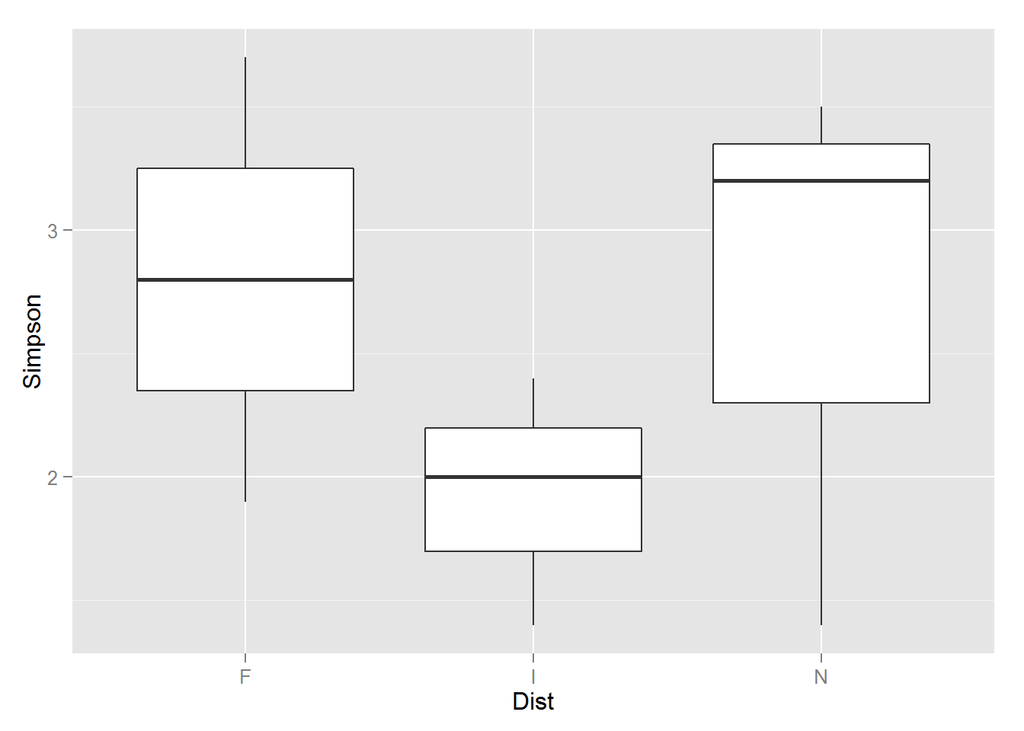

```r
ggplot(blbees, aes(Dist, Simpson))+
  geom_boxplot()
```

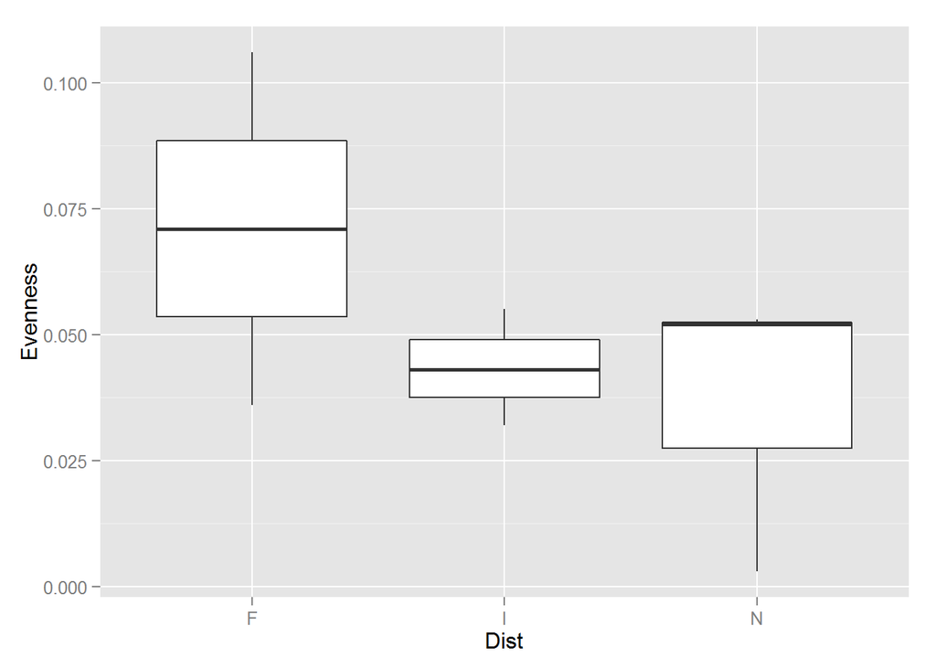

```r
ggplot(blbees, aes(Dist, Evenness))+
  geom_boxplot()
```

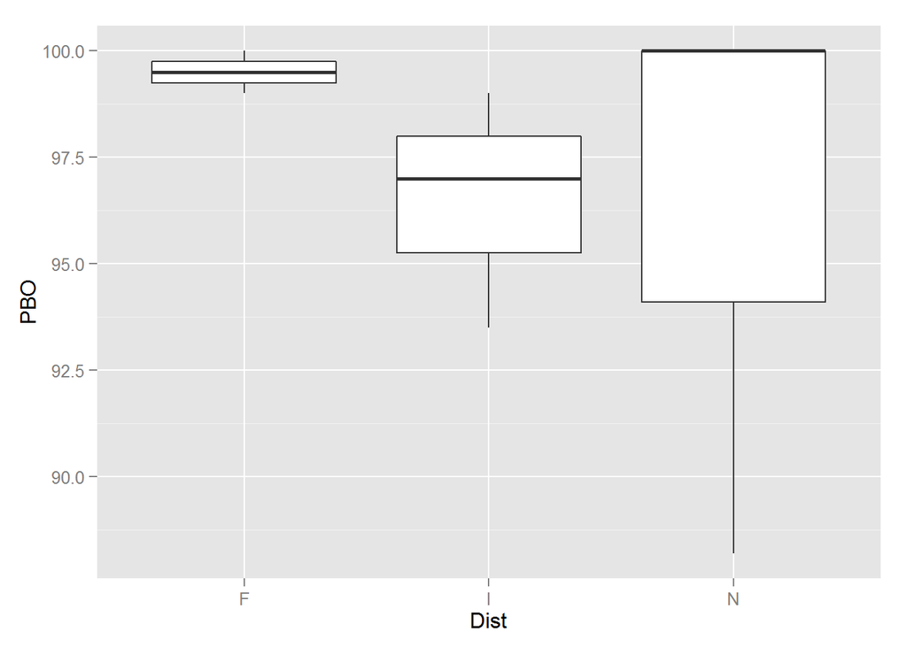

```r
ggplot(blbees, aes(Dist, PBO))+
  geom_boxplot()
```